# Project 2

Name: Kira Degelsmith Partner: Felix Lopez

2025-05-21

# GitHub link

[Felix and Kira Project 2 GitHub Repo](https://github.com/kadegel/Felix-Kira-Project-2)

# Data

## WHO Global Data

Added by Kira Degelsmith

```bash
curl -L -o confirmed_global.csv https://raw.githubusercontent.com/CSSEGISandData/COVID-19/refs/heads/master/csse_covid_19_data/csse_covid_19_time_series/time_series_covid19_confirmed_global.csv

curl -L -o deaths_global.csv https://raw.githubusercontent.com/CSSEGISandData/COVID-19/refs/heads/master/csse_covid_19_data/csse_covid_19_time_series/time_series_covid19_deaths_global.csv

curl -L -o recovered_global.csv https://raw.githubusercontent.com/CSSEGISandData/COVID-19/refs/heads/master/csse_covid_19_data/csse_covid_19_time_series/time_series_covid19_recovered_global.csv
```

[output not shown]

## USPRT US Data

Added by Felix Lopez

```bash
curl -L -o time_series_covid19_confirmed_US.csv https://raw.githubusercontent.com/CSSEGISandData/COVID-19/master/csse_covid_19_data/csse_covid_19_time_series/time_series_covid19_confirmed_US.csv

curl -L -o time_series_covid19_deaths_US.csv https://raw.githubusercontent.com/CSSEGISandData/COVID-19/master/csse_covid_19_data/csse_covid_19_time_series/time_series_covid19_deaths_US.csv
```

[output not shown]

## Read Data

```r
confirmed_global <- read_csv('confirmed_global.csv')
deaths_global <- read_csv('deaths_global.csv')
recovered_global <- read_csv('recovered_global.csv')
confirmed_us <- read_csv("time_series_covid19_confirmed_US.csv")
deaths_us <- read_csv("time_series_covid19_deaths_US.csv")
```

# Project Objectives

## Objective 1

The following code creates a customized world map with color coding based on the severity of COVID-19 in each country. The markers may be hovered over to view country names, and the check boxes allow for the choice to view confirmed cases, deaths, or both.

```r
# Create data frame with country total confirmed cases and mean long/lat
global_conf_totals <- confirmed_global %>%
  mutate(conf = rowSums(across(5:ncol(confirmed_global)))) %>%
  group_by(`Country/Region`) %>%
  summarize(mean_lat = mean(Lat, na.rm=TRUE),
            mean_long = mean(Long, na.rm=TRUE),
            total_conf = sum(conf, na.rm=TRUE))

# Find levels
levels_conf <- quantile(global_conf_totals$total_conf,
                           prob=c(.2,.4,.6,.8),
                           type=1)

# Set rank levels
rank_levels <- c('very low', 'low', 'mid', 'high', 'very high')

# Add rank levels to the data frame
global_conf_rank <- global_conf_totals %>%
  mutate(rank = factor(case_when(
    total_conf <= levels_conf[1] ~ 'very low',
    total_conf <= levels_conf[2] ~ 'low',
    total_conf <= levels_conf[3] ~ 'mid',
    total_conf <= levels_conf[4] ~ 'high',
    TRUE ~ 'very high'),
    levels = rank_levels))

# Create data frame with death totals and mean long/lat
global_death_totals <- deaths_global %>%
  mutate(deaths = rowSums(across(5:ncol(deaths_global)))) %>%
  group_by(`Country/Region`) %>%
  summarize(mean_lat = mean(Lat, na.rm=TRUE),
            mean_long = mean(Long, na.rm=TRUE),
            total_deaths = sum(deaths, na.rm=TRUE))

# Find levels
levels_death <- quantile(global_death_totals$total_deaths,
                            prob=c(.2,.4,.6,.8),
                            type=1)

# Add rank levels to the data frame
global_deaths_rank <- global_death_totals %>%
  mutate(rank = factor(case_when(
    total_deaths <= levels_death[1] ~ 'very low',
    total_deaths <= levels_death[2] ~ 'low',
    total_deaths <= levels_death[3] ~ 'mid',
    total_deaths <= levels_death[4] ~ 'high',
    TRUE ~ 'very high'),
    levels = rank_levels))

# Map colors to levels
cols <- colorFactor(palette = c('darkblue', 'lightblue', 'grey', 'orange', 'red'),
                    levels = c('very low', 'low', 'mid', 'high', 'very high'))

# Create leaflet map visualization
leaflet() %>%
  addProviderTiles('CartoDB.Positron') %>%
  setView(lat = 15, lng = 0, zoom = 1.5) %>%
  addCircleMarkers(data = global_conf_rank,
                   lng = ~mean_long,
                   lat = ~mean_lat,
                   color = ~cols(rank),
                   radius = 4,
                   opacity = 0.75,
                   label = ~`Country/Region`,
                   group = 'Confirmed') %>%
  addCircleMarkers(data = global_deaths_rank,
                   lng = ~mean_long,
                   lat = ~mean_lat,
                   color = ~cols(rank),
                   radius = 4,
                   opacity = 0.75,
                   label = ~`Country/Region`,
                   group = 'Deaths') %>%
  addLayersControl(overlayGroups = c('Confirmed', 'Deaths'),
                   options = layersControlOptions(collapsed = FALSE)) %>%
  addLegend(position = "bottomleft",
            pal = cols,
            values = global_conf_rank$rank,
            title = 'COVID-19 Severity',
            opacity = 1)
```

[interactive chart not shown]

## Objective 2

The following code creates a scroll table to show the amount of COVID-19 deaths and confirmations by country in order of count, where the countries with the most confirmations/deaths are shown first.

```r
# Arrange and clean global confirmed and death totals data frames
global_conf_clean <- global_conf_totals %>%
  rename(Country = `Country/Region`, Count = total_conf) %>%
  select(Country, Count) %>%
  arrange(-Count) %>%
  mutate(Rank = c(1:nrow(global_conf_totals))) %>%
  relocate(Rank, .before = Country)
global_death_clean <- global_death_totals %>%
  rename(Country = `Country/Region`, Count = total_deaths) %>%
  select(Country, Count) %>%
  arrange(-Count)

# Format data frames to have commas for clarity
global_conf_clean$Count <- format(global_conf_clean$Count, big.mark = ',',
                                  scientific = FALSE)
global_death_clean$Count <- format(global_death_clean$Count, big.mark = ',',
                                   scientific = FALSE)

# Build scroll kable table with formatting
kbl(cbind(global_conf_clean, global_death_clean)) %>%
  add_header_above(c(' ' = 1,'Confirmations' = 2, 'Deaths' = 2)) %>%
  kable_styling(bootstrap_options = 'striped') %>%
  scroll_box(width = '100%', height = '400px')
```

| Rank | Confirmations Country | Confirmations Count | Deaths Country | Deaths Count |
| --- | --- | --- | --- | --- |
| 1 | US | 53,813,184,406 | US | 713,877,215 |
| 2 | India | 29,131,119,694 | Brazil | 488,181,000 |
| 3 | Brazil | 21,182,690,594 | India | 364,921,237 |
| 4 | France | 16,105,911,886 | Mexico | 241,085,189 |
| 5 | Germany | 13,686,043,720 | Russia | 220,983,590 |
| 6 | United Kingdom | 12,118,271,679 | Peru | 170,749,849 |
| 7 | Russia | 10,578,569,842 | United Kingdom | 160,836,677 |
| 8 | Italy | 10,083,161,678 | Italy | 127,936,784 |
| 9 | Turkey | 8,840,742,699 | France | 113,410,357 |
| 10 | Korea, South | 8,467,888,968 | Colombia | 100,671,637 |
| 11 | Japan | 7,338,211,631 | Iran | 100,635,059 |
| 12 | Spain | 7,071,275,148 | Indonesia | 100,335,700 |
| 13 | Argentina | 5,625,482,921 | Germany | 96,058,800 |
| 14 | Iran | 4,612,422,449 | Argentina | 91,037,145 |
| 15 | Vietnam | 4,314,591,370 | Spain | 84,574,201 |
| 16 | Colombia | 4,214,829,115 | Poland | 75,801,494 |
| 17 | Netherlands | 4,109,863,466 | South Africa | 71,031,044 |
| 18 | Mexico | 3,944,108,014 | Ukraine | 70,720,601 |
| 19 | Indonesia | 3,692,406,698 | Turkey | 62,808,714 |
| 20 | Poland | 3,643,680,024 | Romania | 41,936,507 |
| 21 | Australia | 3,508,864,881 | Chile | 38,191,355 |
| 22 | Ukraine | 3,190,613,850 | Philippines | 37,362,277 |
| 23 | South Africa | 2,613,099,489 | Canada | 30,262,409 |
| 24 | Peru | 2,499,413,018 | Hungary | 30,193,695 |
| 25 | Czechia | 2,439,147,631 | Czechia | 28,258,087 |
| 26 | Portugal | 2,405,740,042 | Ecuador | 26,441,796 |
| 27 | Malaysia | 2,374,175,078 | Belgium | 25,706,906 |
| 28 | Chile | 2,352,869,754 | Bulgaria | 22,892,110 |
| 29 | Philippines | 2,281,636,877 | Japan | 22,371,798 |
| 30 | Belgium | 2,280,497,649 | Pakistan | 22,288,864 |

[output cut: 171 more lines]

## Objective 3

The following code filters the data to focus on California and reshapes the data to show daily confirmed COVID-19 cases. It creates a statewide trend plot, marking the following key milestones: second vaccine dose, Delta and Omicron variants. It plots the trends over time for the top three counties by case count. Finally, it creates a visualization that compares statewide and county-level patterns side by side.

```r
# Get latest date column
latest_date_us <- names(confirmed_us)[ncol(confirmed_us)]

# Group US confirmed by state
confirmed_us_summary <- confirmed_us %>%
  group_by(Province_State) %>%
  summarise(total_confirmed = sum(!!sym(latest_date_us), na.rm = TRUE))

# Group US deaths by state
deaths_us_summary <- deaths_us %>%
  group_by(Province_State) %>%
  summarise(total_deaths = sum(!!sym(latest_date_us), na.rm = TRUE))

# Merge
us_summary <- left_join(confirmed_us_summary, deaths_us_summary, by = "Province_State")

# Preview of table
head(us_summary)
```

```
## # A tibble: 6 × 3
##   Province_State total_confirmed total_deaths
##   <chr>                    <dbl>        <dbl>
## 1 Alabama                1644533        21032
## 2 Alaska                  307655         1486
## 3 American Samoa            8320           34
## 4 Arizona                2443514        33102
## 5 Arkansas               1006883        13020
## 6 California            12129699       101159
```

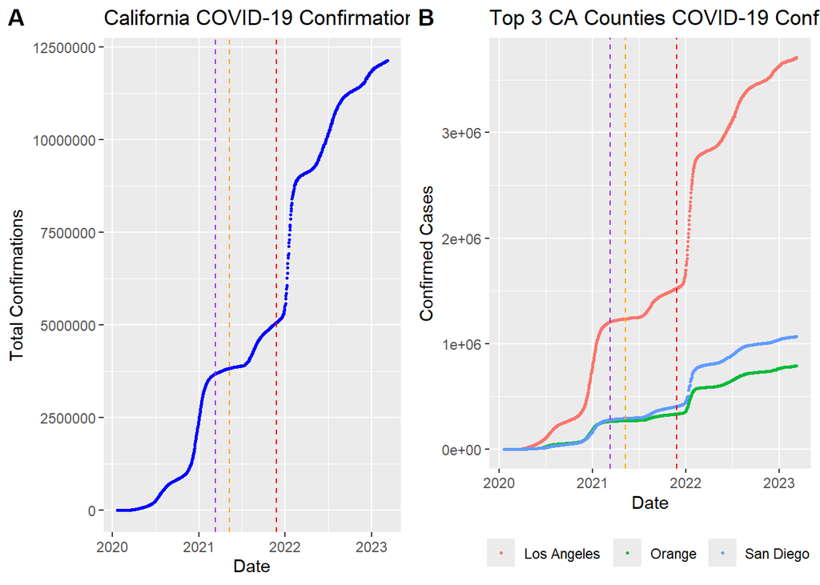

```r
##The code above downloads and processes the US COVID-19 confirmed and death data. It extracts the most recent totals for each state and merges the two datasets into a unified summary.


# Filter for California
ca_data <- confirmed_us %>%
  filter(Province_State == "California")

# Convert the data to long format
ca_long <- ca_data %>%
  pivot_longer(cols = matches("^\\d+/\\d+/\\d+$"),
               names_to = "Date",
               values_to = "Confirmed") %>%
  mutate(Date = as.Date(Date, format = "%m/%d/%y"))
# Sum confirmations across all counties for each date
ca_statewide <- ca_long %>%
  group_by(Date) %>%
  summarize(Total_Confirmed = sum(Confirmed))

# Key dates
second_dose <- as.Date("2021-03-12")
delta_date <- as.Date("2021-05-11")
omicron_date <- as.Date("2021-11-26")

# Create statewide plot
p1 <- ggplot(ca_statewide, aes(x = Date, y = Total_Confirmed)) +
  geom_point(color = "blue", size = 0.5) +
  geom_vline(xintercept = as.numeric(second_dose), color = "purple", linetype = "dashed") +
  geom_vline(xintercept = as.numeric(delta_date), color = "orange", linetype = "dashed") +
  geom_vline(xintercept = as.numeric(omicron_date), color = "red", linetype = "dashed") +
  labs(title = "California COVID-19 Confirmations Over Time",
       x = "Date", y = "Total Confirmations")

# Find top 3 counties by max confirmation
top3_counties <- ca_long %>%
  group_by(Admin2) %>%
  summarize(Max_Confirmed = max(Confirmed)) %>%
  arrange(desc(Max_Confirmed)) %>%
  slice(1:3) %>%
  pull(Admin2)

# Filter for top 3 counties
top3_data <- ca_long %>%
  filter(Admin2 %in% top3_counties)

# Plot top 3 counties
p2 <- ggplot(top3_data, aes(x = Date, y = Confirmed, color = Admin2)) +
  geom_point(size = 0.5) +
  geom_vline(xintercept = as.numeric(second_dose), color = "purple", linetype = "dashed") +
  geom_vline(xintercept = as.numeric(delta_date), color = "orange", linetype = "dashed") +
  geom_vline(xintercept = as.numeric(omicron_date), color = "red", linetype = "dashed") +
  labs(title = "Top 3 CA Counties COVID-19 Confirmations",
       x = "Date", y = "Confirmed Cases") +
  theme(legend.position = "bottom", legend.title = element_blank())

plot_grid(p1, p2, labels = c("A", "B"))
```

## Objective 4

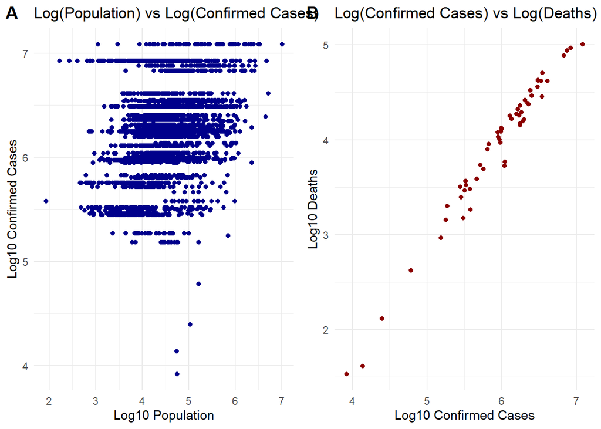

```r
# Merge population data from deaths_us (which contains Population column)
us_summary <- us_summary %>%
  left_join(deaths_us %>% select(Province_State, Population), by = "Province_State") %>%
  filter(Population > 0, total_confirmed > 0, total_deaths > 0)

# Add log-transformed columns
us_summary <- us_summary %>%
  mutate(
    log_population = log10(Population),
    log_confirmed = log10(total_confirmed),
    log_deaths = log10(total_deaths)
  )

# Scatter plot: Population vs Confirmed Cases
pop_vs_confirmed <- ggplot(us_summary, aes(x = log_population, y = log_confirmed)) +
  geom_point(color = "darkblue") +
  labs(
    title = "Log(Population) vs Log(Confirmed Cases)",
    x = "Log10 Population",
    y = "Log10 Confirmed Cases"
  ) +
  theme_minimal()

# Scatter plot: Confirmed Cases vs Deaths
confirmed_vs_deaths <- ggplot(us_summary, aes(x = log_confirmed, y = log_deaths)) +
  geom_point(color = "darkred") +
  labs(
    title = "Log(Confirmed Cases) vs Log(Deaths)",
    x = "Log10 Confirmed Cases",
    y = "Log10 Deaths"
  ) +
  theme_minimal()

# Combine plots using cowplot
plot_grid(pop_vs_confirmed, confirmed_vs_deaths, labels = c("A", "B"))
```

# GitHub Log

```bash
git log --pretty=format:"%nSubject: %s%nAuthor: %aN%nDate: %aD%nBody: %b"
```

```
##
## Subject: edit obj2 kable formatting and clean up read_data file
## Author: kadegel
## Date: Wed, 21 May 2025 19:05:28 -0700
## Body:
##
## Subject: Resolve merge conflict in Project2_writeup.Rmd
## Author: FEL1HIL
## Date: Wed, 21 May 2025 18:03:07 -0700
## Body:
##
## Subject: Add Objective 4 analysis and plots
## Author: FEL1HIL
## Date: Wed, 21 May 2025 17:56:10 -0700
## Body:
##
## Subject: finalize objective 2 and add it to writeup
## Author: kadegel
## Date: Sun, 18 May 2025 16:52:01 -0700
## Body:
##
## Subject: add obj2.R
## Author: kadegel
## Date: Sun, 18 May 2025 15:58:11 -0700
## Body:
##
## Subject: finalize objective 1 and add it to writeup
## Author: kadegel
## Date: Sun, 18 May 2025 15:12:27 -0700
## Body:
##
## Subject: Update Project2 writeup with new analysis and fixes
## Author: FEL1HIL
## Date: Sat, 17 May 2025 16:10:20 -0700
## Body:
##
## Subject: Added US data download and summary (Felix)
## Author: FEL1HIL
## Date: Sat, 17 May 2025 13:41:09 -0700
## Body:
```

[output cut: 30 more lines]

```
##
## Subject: add team member assignments to readme file
## Author: kadegel
## Date: Tue, 13 May 2025 20:50:04 -0700
## Body:
##
## Subject: add team member names to readme file
## Author: kadegel
## Date: Tue, 13 May 2025 20:39:47 -0700
## Body:
##
## Subject: Initial commit
## Author: kadegel
## Date: Tue, 13 May 2025 20:13:57 -0700
## Body:
```